# STA100 Lab7

Chi Po Choi

11/11/2021

# Exercise in `Discussion-07.pdf`

Get the `Discussion-07.pdf` prepared by Maxime in [STA100B Piazza Resources](https://piazza.com/ucdavis/fall2021/sta100b/resources) .

# Hints

#### Discussion-07

- Q2 (a-b)

  | Brand | A | B | C |
  | --- | --- | --- | --- |
  | $\bar{y}_i$ | 10.5 | 10.6 | 8.2 |
  | $s_i$ | 2.1 | 2.2 | 4.8 |
  | $n_i$ | 25 | 25 | 25 |

  $$\begin{aligned}
  H_0:& \mu_A = \mu_B = \mu_C \\
  H_A:& \text{Not all $\mu_A, \mu_B, \mu_C$ are equal.}
  \end{aligned}$$

  The F test statistics
  $$\begin{aligned}
  \bar{\bar{y}}
  &=
  \frac{
  25 \times 10.5 + 25 \times 10.6 + 25 \times 8.2
  }{
  25+25+25
  }
  =
  9.7667
  \\
  MS(\text{Between})
  &=
  \frac{
  SS(\text{Between})
  }{
  \text{d.f.}(\text{Between})
  }
  =
  \frac{
  25 \times (10.5 - 9.7667)^2
  + 25 \times (10.6 - 9.7667)^2
  + 25 \times (8.2 - 9.7667)^2
  }{
  3 - 1
  }
  =
  46.0833
  \\
  MS(\text{Within})
  &=
  \frac{
  SS(\text{Within})
  }{
  \text{d.f.}(\text{Within})
  }
  = 10.6159 \quad \text{(given in this question)}
  \\
  F
  &=
  \frac{MS(\text{Between})}{MS(\text{Within})}
  =
  \frac{46.0833}{10.6159}
  =
  4.3410
  \end{aligned}$$

  Look at the F distribution table:
  - Numerator df $= 3 - 1 = 2$
  - Denom. df $= 75 - 3 = 72$
  - F $\sim (4.18, 4.98)$
  - p-value $\sim (0.01, 0.02)$
- Q2 (c)

  $\alpha = 0.05$, while p-value is between $0.01$ and $0.02$.

  p-value is smaller than $\alpha$, therefore $H_0$ null hypothesis is rejected.
- Q2 (d)

  The ANOVA analysis here assumes equal variance across all brand (though they could have difference population mean). The sample standard deviation of Brand C is a much higher than that of A and B. It is suspicious that Brand C could have differerent variance than A and B.

#### Homework 5

- R Homework I

Lets load the DRP data and plot it. Note that we use the function `factor` to set up the categorical variable `Treatment` in the way that “Treated” is at front and “Control” is at back.

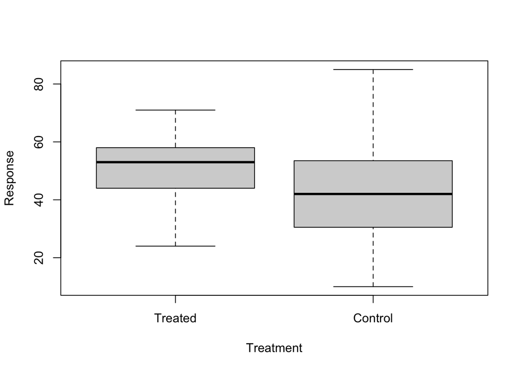

```r
data_drp <- read.csv("DRP.csv")
data_drp$Treatment = factor(data_drp$Treatment, levels = c("Treated", "Control")) #important line!
boxplot(Response ~ Treatment, data = data_drp)
```

Lets compute the two-sided confidence interval for the difference in population means. The difference is
$$\mu_\text{Treatment} - \mu_\text{Control}$$
We use the function `t.test` to compute the two-sided confidence interval:

```r
t.test(Response ~ Treatment,
       data = data_drp,
       conf.level = 0.95)
```

```
##
##  Welch Two Sample t-test
##
## data:  Response by Treatment
## t = 2.3109, df = 37.855, p-value = 0.02638
## alternative hypothesis: true difference in means is not equal to 0
## 95 percent confidence interval:
##   1.23302 18.67588
## sample estimates:
## mean in group Treated mean in group Control
##              51.47619              41.52174
```

From the output of `t.test`, we see that the 95 percent confidence interval of the difference in average DRP score between “Treated” and “Control” is $(1.23302, 18.67588)$.

We use the function `t.test` again, but with the option `alternative = "greater"` for the hypothesis
$$\begin{aligned}
H_0:& \quad \mu_\text{Treatment} - \mu_\text{Control} \leq 0 \\
H_A:& \quad \mu_\text{Treatment} - \mu_\text{Control} > 0
\end{aligned}$$

```r
t.test(Response ~ Treatment,
       data = data_drp,
       alternative = "greater")
```

```
##
##  Welch Two Sample t-test
##
## data:  Response by Treatment
## t = 2.3109, df = 37.855, p-value = 0.01319
## alternative hypothesis: true difference in means is greater than 0
## 95 percent confidence interval:
##  2.691293      Inf
## sample estimates:
## mean in group Treated mean in group Control
##              51.47619              41.52174
```

We can see the test statistics and p-value for this hypothesis.

- R Homework II

Lets load the IQ data and plot it.

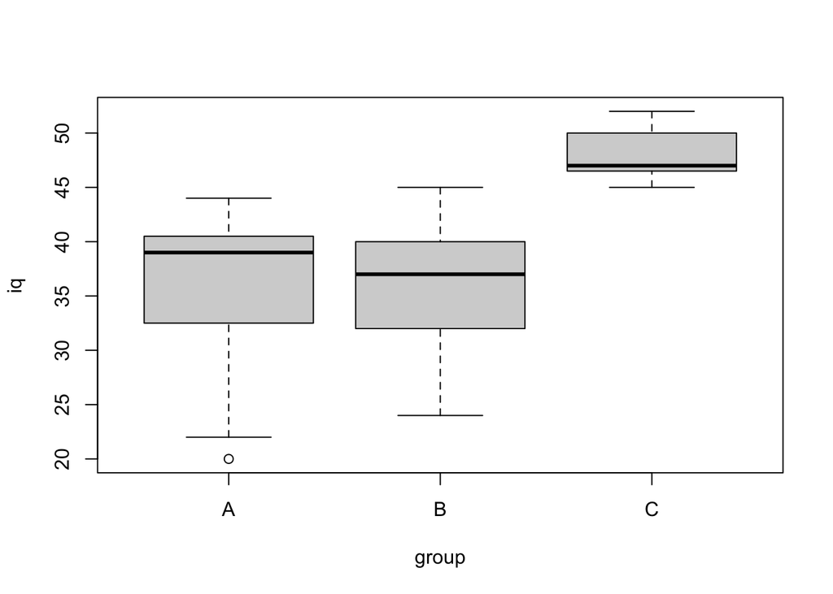

```r
data_iq <- read.csv("IQ.csv")
data_iq$group <- factor(data_iq$group, levels = c("A", "B", "C"))

boxplot(iq ~ group, data = data_iq)
```

We may consider the hypothesis
$$\begin{aligned}
H_0:& \quad \mu_A = \mu_B = \mu_C \\
H_A:& \quad \text{not all equal}.
\end{aligned}$$
Let use the `lm` and `anova` functions to find out the F test corresponding to this hypothesis.

```r
model_iq <- lm(iq ~ group, data = data_iq)
anova(model_iq)
```

```
## Analysis of Variance Table
##
## Response: iq
##           Df Sum Sq Mean Sq F value    Pr(>F)
## group      2 1529.4  764.69  20.016 7.843e-07 ***
## Residuals 42 1604.5   38.20
## ---
## Signif. codes:  0 '***' 0.001 '**' 0.01 '*' 0.05 '.' 0.1 ' ' 1
```

The F test statistics is 20.016 with d.f. being 2.

We can plot the Normal Probability Plot for IQ scores, with all group together.

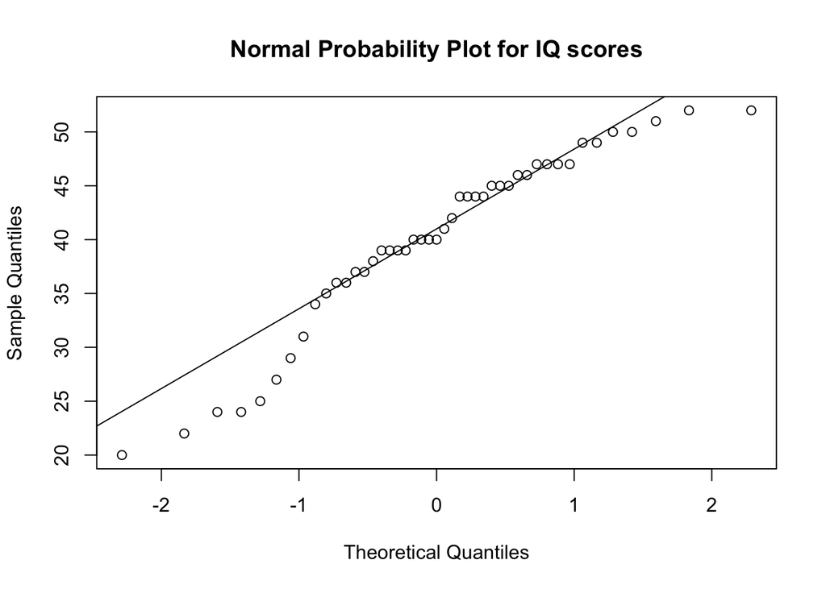

```r
qqnorm(data_iq$iq, main = "Normal Probability Plot for IQ scores")
qqline(data_iq$iq)
```

We can plot the Normal Probability Plot for IQ scores with each group individually.

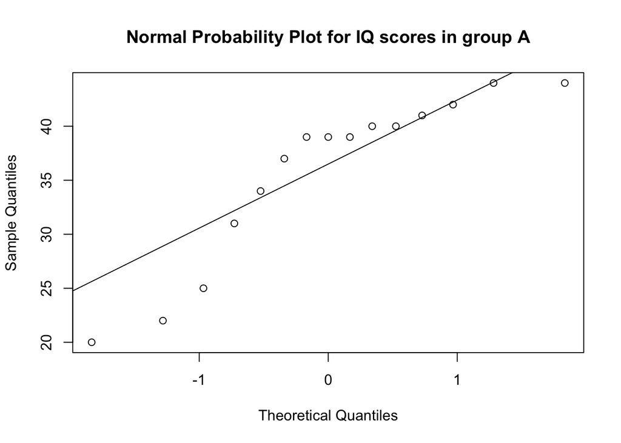

```r
index_A = data_iq$group == "A"
qqnorm(data_iq$iq[index_A], main = "Normal Probability Plot for IQ scores in group A")
qqline(data_iq$iq[index_A])
```

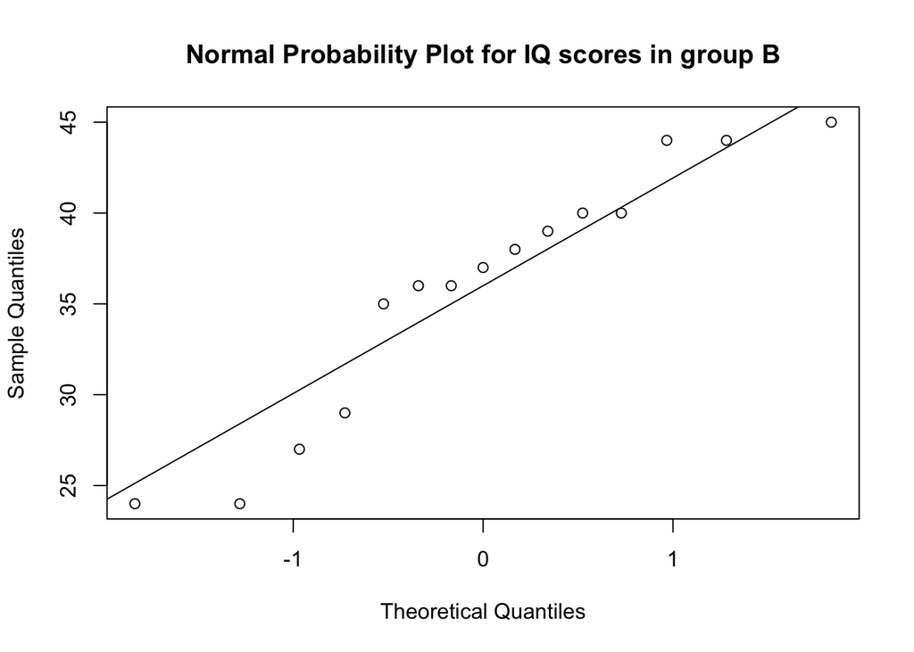

```r
index_B = data_iq$group == "B"
qqnorm(data_iq$iq[index_B], main = "Normal Probability Plot for IQ scores in group B")
qqline(data_iq$iq[index_B])
```

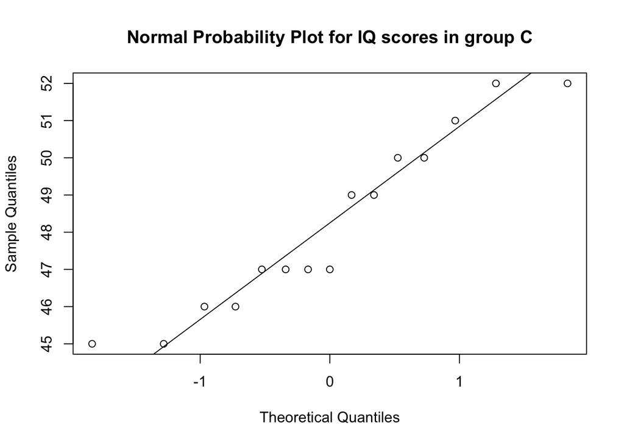

```r
index_C = data_iq$group == "C"
qqnorm(data_iq$iq[index_C], main = "Normal Probability Plot for IQ scores in group C")
qqline(data_iq$iq[index_C])
```